# Установка пакетов для курса

После успешной установки соберите Qmd-файл, он выполнит все команды с проверками, и загрузите его в [папку на Google Drive](https://drive.google.com/drive/folders/1EZlbhXI3Xg-mnD3VpUq7tKLO21utrk5P?usp=drive_link). Он должен выглядеть так же, как HTML-файл, который вы сейчас читаете.

Все шаги мы разбирали в курсе: установка R и Positron, [установка пакетов](https://stepik.org/lesson/2482463/step/9?unit=2520225) и [сборка отчёта](https://stepik.org/lesson/2482460/step/2?unit=2520222). Ошибки при установке пакетов случаются: попробуйте разобраться по сообщению в консоли, а если не удастся — напишите в чат или преподавателю и приложите сообщение.

```r
# Код в этом чанке установит все необходимые пакеты за один раз
install.packages(
  c(
    "tidyverse",
    "epiR",
    "Hmisc",
    "lmtest",
    "multcomp",
    "pROC",
    "rstatix",
    "sandwich",
    "TrialSize",
    "yardstick",
    "FactoMineR",
    "factoextra",
    "ggbiplot",
    "dagitty",
    "ggdag",
    "corrplot",
    "ggExtra",
    "GGally",
    "ggfortify",
    "ggpubr",
    "pheatmap",
    "plotly",
    "flextable",
    "openxlsx",
    "gtsummary",
    "devtools",
    "knitr",
    "rmarkdown",
    "styler"
  )
)
```

## tidyverse

Набор пакетов для импорта, преобразования и визуализации данных. [Сайт](https://tidyverse.tidyverse.org/).

Установка:

```r
install.packages("tidyverse")
```

Проверка:

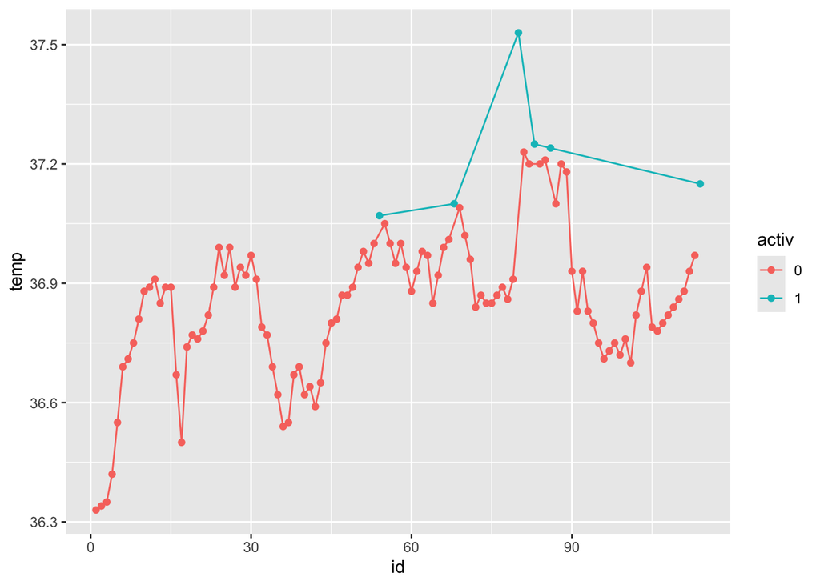

```r
library(ggplot2)
library(dplyr)

beav <- beaver1
beav$id <- 1:nrow(beaver1)
beav <- beav |> mutate(activ = factor(activ))
ggplot(data = beav, aes(x = id, y = temp, group = activ, color = activ)) +
  geom_line() +
  geom_point()
```

## broom

Преобразование результатов статистических моделей в удобные датафреймы. [Туториал](https://cran.r-project.org/web/packages/broom/vignettes/broom.html).

Установка:

```r
install.packages("broom")
```

Проверка:

```r
library(broom)

lmfit <- lm(mpg ~ wt, mtcars)
tidy(lmfit)
```

```
# A tibble: 2 × 5
  term        estimate std.error statistic  p.value
  <chr>          <dbl>     <dbl>     <dbl>    <dbl>
1 (Intercept)    37.3      1.88      19.9  8.24e-19
2 wt             -5.34     0.559     -9.56 1.29e-10
```

## epiR

Эпидемиологические расчёты. [Справка](https://cran.r-project.org/web/packages/epiR/index.html) · [Справка о размере выборки](https://cran.r-project.org/web/packages/epiR/vignettes/epiR_sample_size.html).

Установка:

```r
install.packages("epiR")
```

Проверка:

```r
library(epiR)

epi.sssupc(
  treat = 12,
  control = 11,
  sigma = 2,
  delta = 0.5,
  n = NA,
  power = 0.8,
  r = 1,
  alpha = 0.05,
  sided.test = 2
)
```

```
$n.total
[1] 504

$n.treat
[1] 252

$n.control
[1] 252

$delta
[1] 0.5

$power
[1] 0.8
```

## Hmisc

Много разных функций для подсчёта статистик, моделирования и работы с данными. [Справка](https://cran.r-project.org/web/packages/Hmisc/Hmisc.pdf).

Установка:

```r
install.packages("Hmisc")
```

Проверка:

```r
library(Hmisc)

x1 <- rnorm(100)
x2 <- rnorm(100)
y <- exp(x1 + x2 + rnorm(100))
f <- lm(log(y) ~ x1 + poly(x2, 3), y = TRUE)
abs.error.pred(lp = exp(fitted(f)), y = y)
```

```
Mean/Median |Differences|

                             Mean    Median
|Yi hat - median(Y hat)| 1.738447 0.6513189
|Yi hat - Yi|            3.422932 0.5619200
|Yi - median(Y)|         3.977154 0.6943307


Ratios of Mean/Median |Differences|

                                               Mean    Median
|Yi hat - median(Y hat)|/|Yi - median(Y)| 0.4371082 0.9380528
|Yi hat - Yi|/|Yi - median(Y)|            0.8606485 0.8092973
```

## lmtest

Тесты и диагностические инструменты для линейных моделей. [Справка](https://cran.r-project.org/web/packages/lmtest/).

Установка:

```r
install.packages("lmtest")
```

Проверка:

```r
library("sandwich")
library("lmtest")

data("PetersenCL", package = "sandwich")

m <- lm(y ~ x + year, data = PetersenCL)

coeftest(m, vcov. = vcovHC(m, type = "HC4"))
```

```
t test of coefficients:

              Estimate Std. Error t value Pr(>|t|)
(Intercept)  0.0827971  0.0612603  1.3516   0.1766
x            1.0350704  0.0284344 36.4021   <2e-16 ***
year        -0.0096579  0.0100031 -0.9655   0.3343
---
Signif. codes:  0 '***' 0.001 '**' 0.01 '*' 0.05 '.' 0.1 ' ' 1
```

## multcomp

Множественные сравнения и проверка гипотез. [Справка](https://cran.r-project.org/web/packages/multcomp/index.html).

Установка:

```r
install.packages("multcomp")
```

Проверка:

```r
library(multcomp)

data(swiss)

lmod <- lm(Fertility ~ ., data = swiss)

glht(
  lmod,
  linfct = c(
    "Agriculture = 0",
    "Examination = 0",
    "Education = 0",
    "Catholic = 0",
    "Infant.Mortality = 0"
  )
)
```

```
     General Linear Hypotheses

Linear Hypotheses:
                      Estimate
Agriculture == 0       -0.1721
Examination == 0       -0.2580
Education == 0         -0.8709
Catholic == 0           0.1041
Infant.Mortality == 0   1.0770
```

## pROC

Анализ классификаторов (ROC-анализ). [Сайт](https://xrobin.github.io/pROC/) · [Справка](https://cran.r-project.org/web/packages/pROC/index.html).

Установка:

```r
install.packages("pROC")
```

Проверка:

```r
library(pROC)

data(aSAH)

roc(outcome ~ s100b, aSAH)
```

```
Call:
roc.formula(formula = outcome ~ s100b, data = aSAH)

Data: s100b in 72 controls (outcome Good) < 41 cases (outcome Poor).
Area under the curve: 0.7314
```

## rstatix

Статистические тесты с единообразным синтаксисом. Удобны для автоматизации. [Страница пакета на CRAN](https://cran.r-project.org/web/packages/rstatix/index.html) · [Сайт](https://rpkgs.datanovia.com/rstatix/).

Установка:

```r
install.packages("rstatix")
```

Проверка:

```r
library(rstatix)
library(dplyr)

data("ToothGrowth")

ToothGrowth |> t_test(len ~ 1, mu = 0)
```

```
# A tibble: 1 × 7
  .y.   group1 group2         n statistic    df        p
* <chr> <chr>  <chr>      <int>     <dbl> <dbl>    <dbl>
1 len   1      null model    60      19.1    59 6.94e-27
```

## sandwich

Робастные матрицы ковариаций для статистических моделей. [Страница пакета на CRAN](https://cran.r-project.org/web/packages/sandwich/index.html) · [Сайт](https://sandwich.r-forge.r-project.org/).

Установка:

```r
install.packages("sandwich")
```

Проверка:

```r
library("sandwich")

data("PetersenCL", package = "sandwich")

m <- lm(y ~ x, data = PetersenCL)

sandwich(m)
```

```
              (Intercept)             x
(Intercept)  8.040060e-04 -1.151437e-05
x           -1.151437e-05  8.059627e-04
```

## TrialSize

Расчёт размера выборки. [Справка](https://cran.r-project.org/web/packages/TrialSize/TrialSize.pdf).

Установка:

```r
install.packages("TrialSize")
```

Проверка:

```r
library(TrialSize)

DLT <- c(0.01, 0.014, 0.025, 0.056, 0.177, 0.594, 0.963)
Example.11.6.2 <- AB.withDescalation(
  A = 3,
  B = 3,
  C = 1,
  D = 1,
  E = 1,
  DLT = DLT
)
Example.11.6.2
```

```
[1] 5.31263168 6.36179955 7.49007589 8.26562781 7.34913225 3.16895651 0.02162551
```

```r
# Example.11.6.2[7]=0.2
```

## yardstick

Метрики качества классификации и регрессии. [Справка](https://cran.r-project.org/web/packages/yardstick/yardstick.pdf).

Установка:

```r
install.packages("yardstick")
```

Проверка:

```r
library(yardstick)
library(dplyr)

data("two_class_example")
data("hpc_cv")
# Two class
accuracy(two_class_example, truth, predicted)
```

```
# A tibble: 1 × 3
  .metric  .estimator .estimate
  <chr>    <chr>          <dbl>
1 accuracy binary         0.838
```

## FactoMineR

Многомерный исследовательский анализ. [Справка](https://cran.r-project.org/web/packages/FactoMineR/FactoMineR.pdf).

Установка:

```r
install.packages("FactoMineR")
```

Проверка:

```r
library(FactoMineR)

## Example two-way anova
data(senso)
res <- AovSum(Score ~ Product + Day, data = senso)
res
```

```
Ftest
               SS df      MS F value   Pr(>F)
Product    2.0278  2  1.0139  3.4428  0.04148 *
Day       25.4725  1 25.4725 86.4959 1.18e-11 ***
Residuals 12.0742 41  0.2945
---
Signif. codes:  0 '***' 0.001 '**' 0.01 '*' 0.05 '.' 0.1 ' ' 1

Ttest
             Estimate Std. Error t value Pr(>|t|)
(Intercept)  4.590736   0.081464 56.3528  < 2e-16 ***
Product - 1  0.237057   0.120675  1.9644  0.05628 .
Product - 2 -0.284745   0.114663 -2.4833  0.01720 *
Product - 3  0.047688   0.118456  0.4026  0.68935
Day - 1      0.803378   0.086382  9.3003  < 2e-16 ***
Day - 2     -0.803378   0.086382 -9.3003  < 2e-16 ***
---
Signif. codes:  0 '***' 0.001 '**' 0.01 '*' 0.05 '.' 0.1 ' ' 1
```

## factoextra

Визуализация результатов анализа главных компонент (PCA), кластеризации и факторного анализа (FA). [Справка](https://cran.r-project.org/web/packages/factoextra/factoextra.pdf).

Установка:

```r
install.packages("factoextra")
```

Проверка:

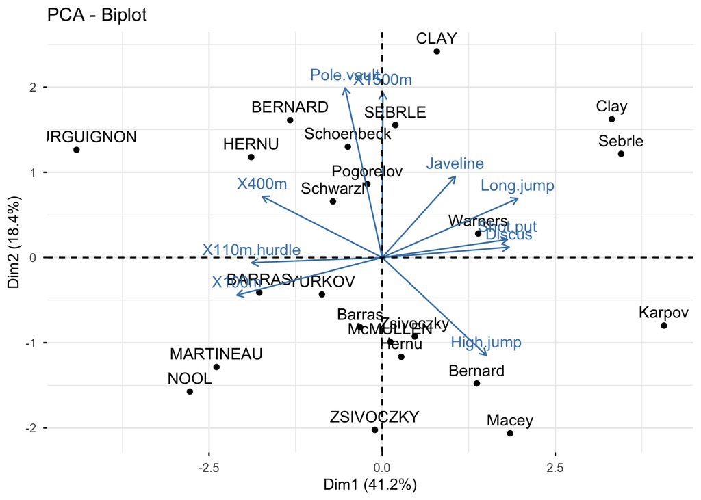

```r
library(factoextra)

data(decathlon2)
decathlon.active <- decathlon2[1:23, 1:10]
res.pca <- prcomp(decathlon.active, scale = TRUE)
fviz_pca_biplot(res.pca)
```

## ggbiplot

Графики для результатов анализа главных компонент (PCA). [Туториал](https://cran.r-project.org/web/packages/ggbiplot/readme/README.html).

Установка:

```r
install.packages("ggbiplot")
```

Проверка:

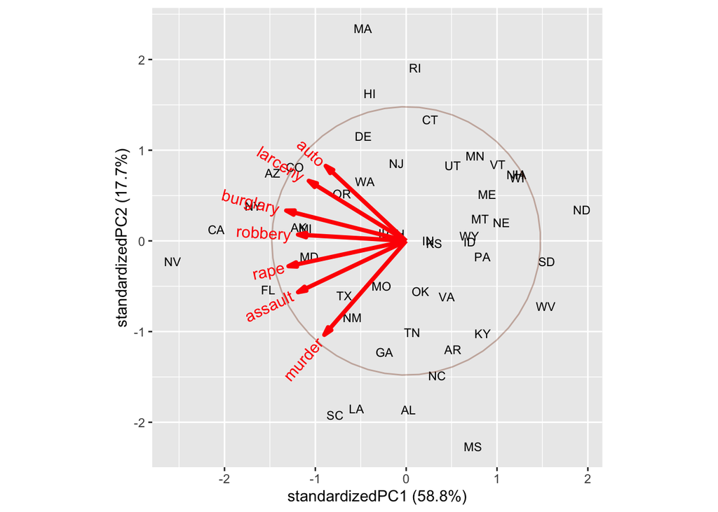

```r
library(ggplot2)
library(ggbiplot)

crime.pca <-
  crime |>
  dplyr::select(where(is.numeric)) |>
  prcomp(scale. = TRUE)

ggbiplot(
  crime.pca,
  labels = crime$st,
  circle = TRUE,
  varname.size = 4,
  varname.color = "red"
)
```

## dagitty

Инструменты для помощи с причинно-следственным выводом. [Справка](https://cran.r-project.org/web/packages/dagitty/dagitty.pdf).

Установка:

```r
install.packages("dagitty")
```

Проверка:

```r
library(dagitty)

g <- dagitty("dag{ z <- x -> y }")
ancestorGraph(g, "z")
```

```
dag {
x
z
x -> z
}
```

```r
g <- dagitty("pdag{ z -- x -> y }")
ancestorGraph(g, "y") # includes z
```

```
pdag {
x
y
z
x -- z
x -> y
}
```

## ggdag

Визуализация диаграмм для причинно-следственного вывода с помощью ggplot2. [Сайт](https://r-causal.github.io/ggdag/).

Установка:

```r
install.packages("ggdag")
```

Проверка:

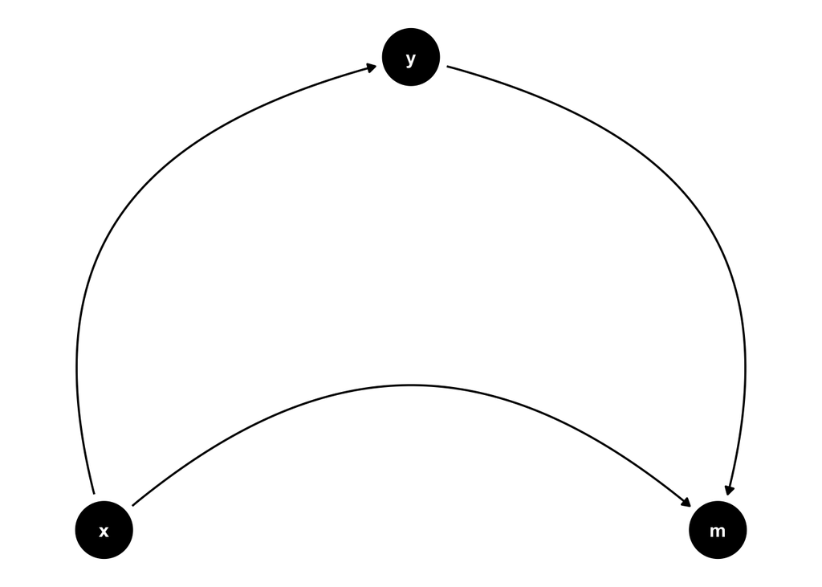

```r
library(dplyr)
library(dagitty)
library(ggplot2)
library(ggdag)

dagify(
  y ~ x,
  m ~ x + y
) |>
  ggplot(aes(x = x, y = y, xend = xend, yend = yend)) +
  geom_dag_point() +
  geom_dag_edges_arc() +
  geom_dag_text() +
  theme_dag()
```

## corrplot

Визуализация корреляционных матриц. [Справка](https://cran.r-project.org/web/packages/corrplot/corrplot.pdf).

Установка:

```r
install.packages("corrplot")
```

Проверка:

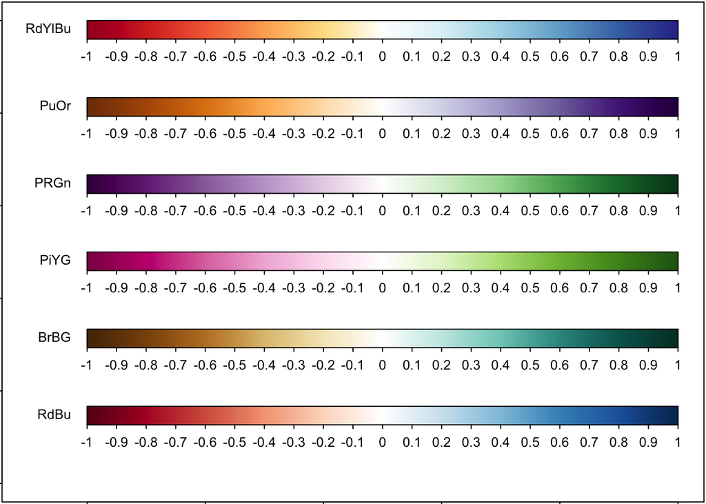

```r
library(corrplot)

## diverging colors
par(mar = c(0, 0, 0, 0) + 0.1)
plot(0, xlim = c(-0.1, 1), ylim = c(0, 1), type = 'n')
col <- c('RdBu', 'BrBG', 'PiYG', 'PRGn', 'PuOr', 'RdYlBu')
for (i in 1:length(col)) {
  colorlegend(
    COL2(col[i]),
    -10:10 / 10,
    align = 'l',
    cex = 0.8,
    xlim = c(0, 1),
    ylim = c(i / length(col) - 0.1, i / length(col)),
    vertical = FALSE
  )
  text(-0.01, i / length(col) - 0.02, col[i], adj = 0.5, pos = 2, cex = 0.8)
}
```

## GGally

Многомерные визуализации для ggplot2. [Сайт](https://ggobi.github.io/ggally/) · [Справка](https://cran.r-project.org/web/packages/GGally/index.html).

Установка:

```r
install.packages("GGally")
```

Проверка:

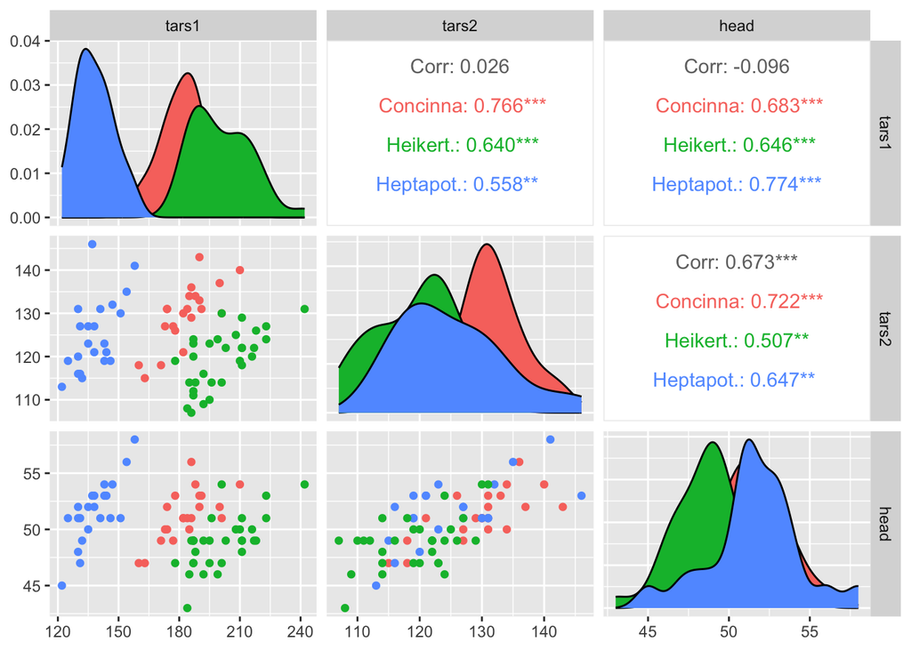

```r
library(GGally)

data(flea)
ggpairs(flea, columns = 2:4, ggplot2::aes(colour = species))
```

## ggExtra

Готовые графики для ggplot2. [Туториал](https://cran.r-project.org/web/packages/ggExtra/vignettes/ggExtra.html).

Установка:

```r
install.packages("ggExtra")
```

Проверка:

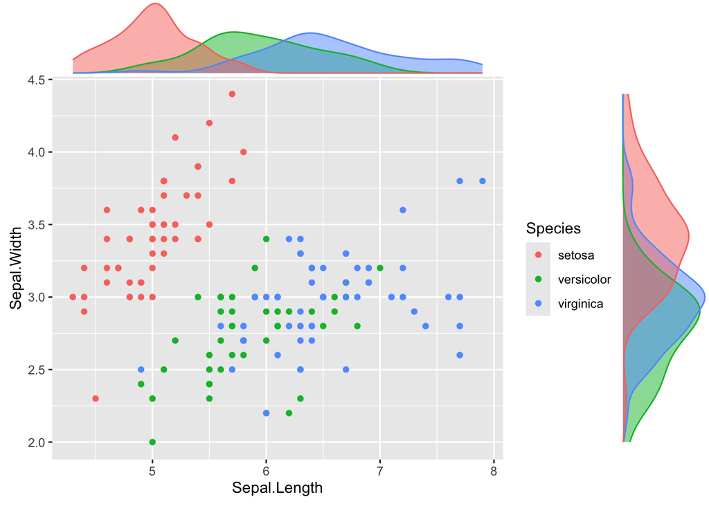

```r
library(ggplot2)
library(ggExtra)

data(iris)

piris <- ggplot(iris, aes(Sepal.Length, Sepal.Width, colour = Species)) +
  geom_point()

ggMarginal(piris, groupColour = TRUE, groupFill = TRUE)
```

## ggfortify

Автоматическое построение графиков для моделей. [Туториал](https://cran.r-project.org/web/packages/ggfortify/vignettes/basics.html) · [Страница пакета на CRAN](https://cran.r-project.org/web/packages/ggfortify/index.html).

Установка:

```r
install.packages("ggfortify")
```

Проверка:

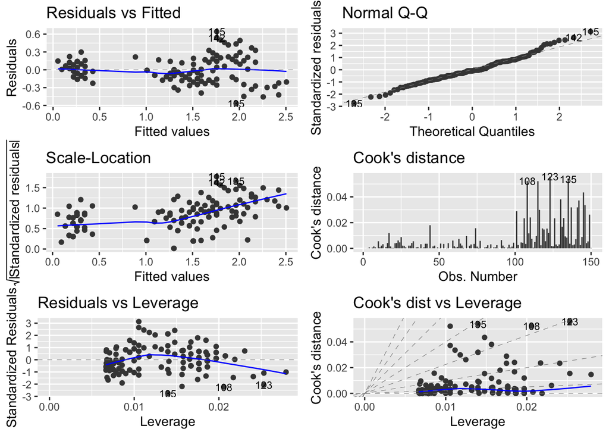

```r
library(ggfortify)

m <- lm(Petal.Width ~ Petal.Length, data = iris)

autoplot(m, which = 1:6, ncol = 2, label.size = 3)
```

## ggpubr

Создает готовые для публикации графики ggplot2. [Сайт](https://rpkgs.datanovia.com/ggpubr/) · [Страница пакета на CRAN](https://cran.r-project.org/web/packages/ggpubr/index.html).

Установка:

```r
install.packages("ggpubr")
```

Проверка:

```r
library(ggpubr)

wdata <- data.frame(
  sex = factor(rep(c("F", "M"), each = 200)),
  weight = c(rnorm(200, 55), rnorm(200, 58))
)
head(wdata, 4)
```

```
  sex   weight
1   F 54.32562
2   F 52.69698
3   F 54.85067
4   F 55.94869
```

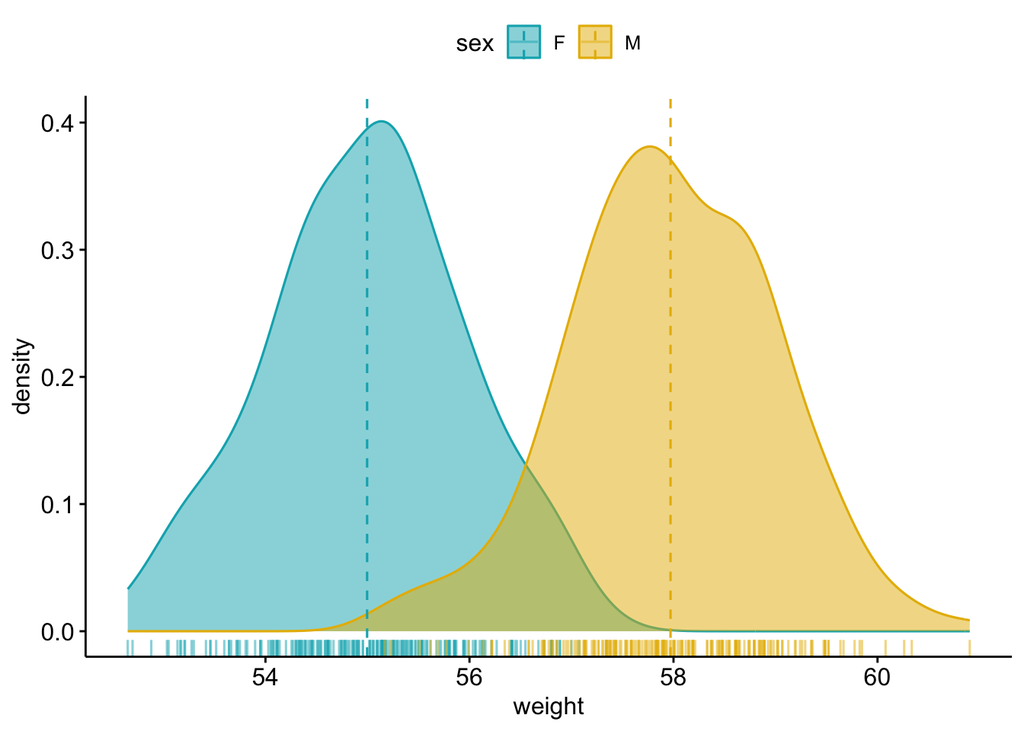

```r
ggdensity(
  wdata,
  x = "weight",
  add = "mean",
  rug = TRUE,
  color = "sex",
  fill = "sex",
  palette = c("#00AFBB", "#E7B800")
)
```

## pheatmap

Тепловые карты с кластеризацией по строкам и столбцам. [Справка](https://cran.r-project.org/web/packages/pheatmap/pheatmap.pdf).

Установка:

```r
install.packages("pheatmap")
```

Проверка:

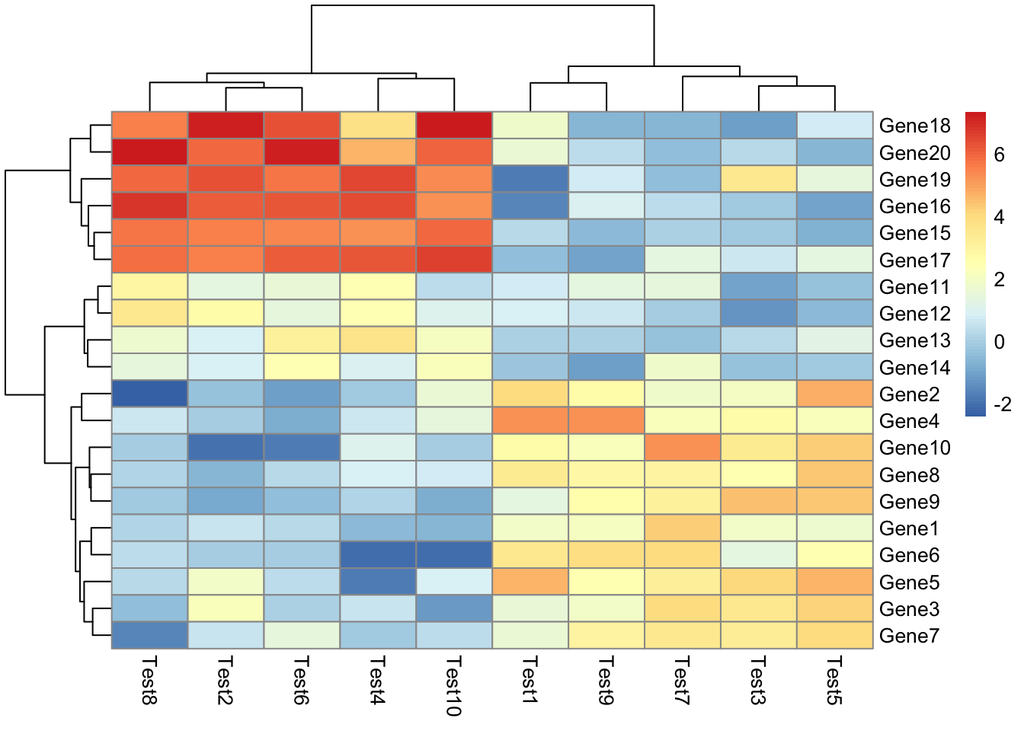

```r
library(pheatmap)

# Create test matrix
test <- matrix(rnorm(200), 20, 10)
test[1:10, seq(1, 10, 2)] <- test[1:10, seq(1, 10, 2)] + 3
test[11:20, seq(2, 10, 2)] <- test[11:20, seq(2, 10, 2)] + 2
test[15:20, seq(2, 10, 2)] <- test[15:20, seq(2, 10, 2)] + 4
colnames(test) <- paste("Test", 1:10, sep = "")
rownames(test) <- paste("Gene", 1:20, sep = "")
# Draw heatmaps
pheatmap(test)
```

## plotly

Интерактивные графики для HTML-отчётов. [Справка](https://cran.r-project.org/web/packages/plotly/plotly.pdf).

Установка:

```r
install.packages("plotly")
```

Проверка:

```r
library(plotly)

plot_ly() |> add_data(economics) |> add_trace(x = ~date, y = ~pce)
```

[interactive chart not shown]

## flextable

Форматирование таблиц для отчётов в HTML, Word, PowerPoint. [Справка](https://cran.r-project.org/web/packages/flextable/).

Установка:

```r
install.packages("flextable")
```

Проверка:

```r
library(flextable)

flextable(mtcars)
```

| mpg | cyl | disp | hp | drat | wt | qsec | vs | am | gear | carb |
| --- | --- | --- | --- | --- | --- | --- | --- | --- | --- | --- |
| 21.0 | 6 | 160.0 | 110 | 3.90 | 2.620 | 16.46 | 0 | 1 | 4 | 4 |
| 21.0 | 6 | 160.0 | 110 | 3.90 | 2.875 | 17.02 | 0 | 1 | 4 | 4 |
| 22.8 | 4 | 108.0 | 93 | 3.85 | 2.320 | 18.61 | 1 | 1 | 4 | 1 |
| 21.4 | 6 | 258.0 | 110 | 3.08 | 3.215 | 19.44 | 1 | 0 | 3 | 1 |
| 18.7 | 8 | 360.0 | 175 | 3.15 | 3.440 | 17.02 | 0 | 0 | 3 | 2 |
| 18.1 | 6 | 225.0 | 105 | 2.76 | 3.460 | 20.22 | 1 | 0 | 3 | 1 |
| 14.3 | 8 | 360.0 | 245 | 3.21 | 3.570 | 15.84 | 0 | 0 | 3 | 4 |
| 24.4 | 4 | 146.7 | 62 | 3.69 | 3.190 | 20.00 | 1 | 0 | 4 | 2 |
| 22.8 | 4 | 140.8 | 95 | 3.92 | 3.150 | 22.90 | 1 | 0 | 4 | 2 |
| 19.2 | 6 | 167.6 | 123 | 3.92 | 3.440 | 18.30 | 1 | 0 | 4 | 4 |
| 17.8 | 6 | 167.6 | 123 | 3.92 | 3.440 | 18.90 | 1 | 0 | 4 | 4 |
| 16.4 | 8 | 275.8 | 180 | 3.07 | 4.070 | 17.40 | 0 | 0 | 3 | 3 |
| 17.3 | 8 | 275.8 | 180 | 3.07 | 3.730 | 17.60 | 0 | 0 | 3 | 3 |
| 15.2 | 8 | 275.8 | 180 | 3.07 | 3.780 | 18.00 | 0 | 0 | 3 | 3 |
| 10.4 | 8 | 472.0 | 205 | 2.93 | 5.250 | 17.98 | 0 | 0 | 3 | 4 |
| 10.4 | 8 | 460.0 | 215 | 3.00 | 5.424 | 17.82 | 0 | 0 | 3 | 4 |
| 14.7 | 8 | 440.0 | 230 | 3.23 | 5.345 | 17.42 | 0 | 0 | 3 | 4 |
| 32.4 | 4 | 78.7 | 66 | 4.08 | 2.200 | 19.47 | 1 | 1 | 4 | 1 |
| 30.4 | 4 | 75.7 | 52 | 4.93 | 1.615 | 18.52 | 1 | 1 | 4 | 2 |
| 33.9 | 4 | 71.1 | 65 | 4.22 | 1.835 | 19.90 | 1 | 1 | 4 | 1 |
| 21.5 | 4 | 120.1 | 97 | 3.70 | 2.465 | 20.01 | 1 | 0 | 3 | 1 |
| 15.5 | 8 | 318.0 | 150 | 2.76 | 3.520 | 16.87 | 0 | 0 | 3 | 2 |
| 15.2 | 8 | 304.0 | 150 | 3.15 | 3.435 | 17.30 | 0 | 0 | 3 | 2 |
| 13.3 | 8 | 350.0 | 245 | 3.73 | 3.840 | 15.41 | 0 | 0 | 3 | 4 |
| 19.2 | 8 | 400.0 | 175 | 3.08 | 3.845 | 17.05 | 0 | 0 | 3 | 2 |
| 27.3 | 4 | 79.0 | 66 | 4.08 | 1.935 | 18.90 | 1 | 1 | 4 | 1 |
| 26.0 | 4 | 120.3 | 91 | 4.43 | 2.140 | 16.70 | 0 | 1 | 5 | 2 |
| 30.4 | 4 | 95.1 | 113 | 3.77 | 1.513 | 16.90 | 1 | 1 | 5 | 2 |
| 15.8 | 8 | 351.0 | 264 | 4.22 | 3.170 | 14.50 | 0 | 1 | 5 | 4 |
| 19.7 | 6 | 145.0 | 175 | 3.62 | 2.770 | 15.50 | 0 | 1 | 5 | 6 |
| 15.0 | 8 | 301.0 | 335 | 3.54 | 3.570 | 14.60 | 0 | 1 | 5 | 8 |
| 21.4 | 4 | 121.0 | 109 | 4.11 | 2.780 | 18.60 | 1 | 1 | 4 | 2 |

## openxlsx

Чтение и создание Excel-файлов без установки Excel. [Справка](https://cran.r-project.org/web/packages/openxlsx/openxlsx.pdf).

Установка:

```r
install.packages("openxlsx")
```

Проверка:

```r
library(openxlsx)

wb <- createWorkbook()
addWorksheet(wb, sheetName = "S1")
addWorksheet(wb, sheetName = "S2")
addWorksheet(wb, sheetName = "S3")
activeSheet(wb) # default value is the first sheet active
```

```
[1] 1
```

```r
activeSheet(wb) <- 1 ## active sheet S1
activeSheet(wb)
```

```
[1] 1
```

```r
activeSheet(wb) <- "S2" ## active sheet S2
activeSheet(wb)
```

```
[1] 2
```

## gtsummary

Готовые статистические таблицы для отчётов. [Сайт](https://www.danieldsjoberg.com/gtsummary/).

Установка:

```r
install.packages("gtsummary")
```

Проверка:

```r
library(gtsummary)

tbl_summary(trial, include = c(age, grade, response), by = trt)
```

| **Characteristic** | **Drug A** N = 98<sup>1</sup> | **Drug B** N = 102<sup>1</sup> |
| --- | --- | --- |
| Age | 46 (37, 60) | 48 (39, 56) |
| Unknown | 7 | 4 |
| Grade |  |  |
| I | 35 (36%) | 33 (32%) |
| II | 32 (33%) | 36 (35%) |
| III | 31 (32%) | 33 (32%) |
| Tumor Response | 28 (29%) | 33 (34%) |
| Unknown | 3 | 4 |

<sup>1</sup> Median (Q1, Q3); n (%)

## devtools

Инструменты для разработки, установки и проверки R-пакетов. [Сайт](https://devtools.r-lib.org/).

Установка:

```r
install.packages("devtools")
```

Проверка:

*Пути к установленным пакетам и их перечень при проверке скрипта на вашем компьютере могут отличаться.*

```r
library(devtools)

loaded_packages()
```

```
      package
1    devtools
2     usethis
3   gtsummary
4    openxlsx
5   flextable
6      plotly
7    pheatmap
8      ggpubr
9   ggfortify
10    ggExtra
11     GGally
12   corrplot
13      ggdag
14    dagitty
```

[output cut: 69 more lines]

## knitr

Дополнительные возможности для Quarto и RMarkdown. [Справка](https://cran.r-project.org/web/packages/knitr/knitr.pdf) · [Сайт](https://yihui.org/knitr/).

Установка:

```r
install.packages("knitr")
```

Проверка:

```r
library(knitr)

kable(head(iris))
```

| Sepal.Length | Sepal.Width | Petal.Length | Petal.Width | Species |
| --- | --- | --- | --- | --- |
| 5.1 | 3.5 | 1.4 | 0.2 | setosa |
| 4.9 | 3.0 | 1.4 | 0.2 | setosa |
| 4.7 | 3.2 | 1.3 | 0.2 | setosa |
| 4.6 | 3.1 | 1.5 | 0.2 | setosa |
| 5.0 | 3.6 | 1.4 | 0.2 | setosa |
| 5.4 | 3.9 | 1.7 | 0.4 | setosa |